# AB_test_puzzle_game1

## This project you find

1.Improt data set with python 2.Check and Cleaning data set 3.Explor data 4.AB test 5.summary article

### import data

This dataset is from Kaggle, and it goes by the name of 'Cookie Cats' mobile game. You can find the dataset [here](https://www.kaggle.com/datasets/yufengsui/mobile-games-ab-testing). Thank you for providing the dataset, and now we can proceed to the next step, which is importing the data.

```python
import pandas as pd
import matplotlib.pyplot as plt
import numpy as np
```

```python
path = 'E:\python\AB test mobile puzzle game\cookie_cats.csv'
df = pd.read_csv(path)
df.head()
```

|  | userid | version | sum_gamerounds | retention_1 | retention_7 |
| --- | --- | --- | --- | --- | --- |
| 0 | 116 | gate_30 | 3 | False | False |
| 1 | 337 | gate_30 | 38 | True | False |
| 2 | 377 | gate_40 | 165 | True | False |
| 3 | 483 | gate_40 | 1 | False | False |
| 4 | 488 | gate_40 | 179 | True | True |

Nice, we have imported the necessary libraries and the dataset is now ready.Go next

### Check and Cleaning data set

If you'd like to check the sample data in the dataset, you can use the `head()` function in Python.

```python
#check type of data
df.info()
```

```
<class 'pandas.core.frame.DataFrame'>
RangeIndex: 90189 entries, 0 to 90188
Data columns (total 5 columns):
 #   Column          Non-Null Count  Dtype
---  ------          --------------  -----
 0   userid          90189 non-null  int64
 1   version         90189 non-null  object
 2   sum_gamerounds  90189 non-null  int64
 3   retention_1     90189 non-null  bool
 4   retention_7     90189 non-null  bool
dtypes: bool(2), int64(2), object(1)
memory usage: 2.2+ MB
```

```python
#check null value in data set
df.isna().sum()
```

```
userid            0
version           0
sum_gamerounds    0
retention_1       0
retention_7       0
dtype: int64
```

`info()` function will display the names of all columns along with their data types.

`.isna().sum()` function will reveal the number of null values in each column.

```python
df['version'] = df['version'].replace({'gate_30':'A','gate_40':'B'})
```

We will replace values from 'gate_30' with 'A' and 'gate_40' with 'B' for easier use

### Explor data

```python
df.groupby('version')['sum_gamerounds'].sum()
```

```
version
A    2344795
B    2333530
Name: sum_gamerounds, dtype: int64
```

We know that each version has a total number of played game rounds.

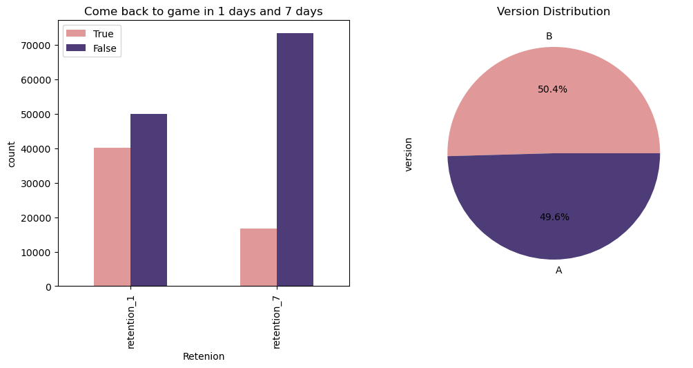

```python
#Export data
fig, (ax1, ax2) = plt.subplots(1, 2, figsize=(12, 5))

reten_df = pd.DataFrame(np.zeros(4).reshape(2,2),index=["retention_1","retention_7"],columns=['True','False'])
reten_df['True'] = [df['retention_1'].sum(), df['retention_7'].sum()]
reten_df['False'] = [len(df) - df['retention_1'].sum(), len(df) - df['retention_7'].sum()]
plot1 = reten_df.plot(kind='bar',title='Come back to game in 1 days and 7 days',color=['#E19898','#4D3C77'],ax=ax1)
plot1.set_xlabel('Retenion')
plot1.set_ylabel('count')


df['version'].value_counts().plot(kind='pie',ax=ax2,autopct='%1.1f%%',colors=['#E19898','#4D3C77'])
ax2.set_title('Version Distribution')
```

### AB test

In this method, I create a function to calculate the variance and the mean. The reason for calculating the variance first is to determine if each group has an equal distribution or not. We start with an F-test to assess the equality of variances; this step is crucial because the subsequent T-test assumes equal variances when comparing means. If the F-test suggests that the variances are statistically equal, we can confidently proceed with the T-test to compare the means of the two groups. The T-test helps us determine whether the means are statistically equal or different. However, if the F-test indicates unequal variances, we may need to adjust our analysis approach or consider using a Welch's T-test, which doesn't assume equal variances. So, the sequence of using the F-test first is essential to ensure the validity of the subsequent T-test, allowing us to draw reliable conclusions about the means of the groups in our AB test.

```python
def A_B_function(dataframe, group, target):
    import scipy.stats as stats

    # Split data by group
    groupA = dataframe[dataframe[group]=='A'][target]
    groupB = dataframe[dataframe[group]=='B'][target]

    n = len(groupB)-(len(groupB)-len(groupA))

    groupA = groupA.sample(n=n,random_state=42)
    groupB = groupB.sample(n=n,random_state=42)
    print("""hypothesis test
    HO: Variances is equal
    H1:Variances is not equal""")
    statistic_Ftest, p_value_Ftest = stats.levene(groupA,groupB)

    alpha = 0.05

    if p_value_Ftest < alpha:
        print("----------------------------------------------------")
        print("Reject H0 hypothesis:Variances is not equal")
        print("----------------------------------------------------")
    else:
        print("----------------------------------------------------")
        print("Fail to reject HO: Variances is equal")
        print("----------------------------------------------------")

    print("""hypothesis test
    HO: mean is not different
    H1:mean is  different""")

    statistic_ttest, p_value_ttest = stats.ttest_rel(groupA,groupB)
    if p_value_ttest < alpha:
        print("----------------------------------------------------")
        print("Reject H0 hypothesis:Variances is not equal")
        print("----------------------------------------------------")
    else:
        print("----------------------------------------------------")
        print("Fail to reject HO: Variances is equal")
        print("----------------------------------------------------")

    meanA = np.mean(groupA)
    meanB = np.mean(groupB)

    print("meandiff:",meanA-meanB)
```

```python
A_B_function(dataframe=df, group='version', target='sum_gamerounds')
```

```
hypothesis test
    HO: Variances is equal
    H1:Variances is not equal
----------------------------------------------------
Fail to reject HO: Variances is equal
----------------------------------------------------
hypothesis test
    HO: mean is not different
    H1:mean is  different
----------------------------------------------------
Fail to reject HO: Variances is equal
----------------------------------------------------
meandiff: 1.1505145413870252
```

In the result of the F-test: When we fail to reject the null hypothesis (HO) that the variances are equal, it means that the variances are indeed equal, allowing us to proceed to the next step.

In the T-test, when the hypothesis test results in a 'Fail to reject HO: Variances are equal,' it suggests that the means may be equal or have only a slight difference.

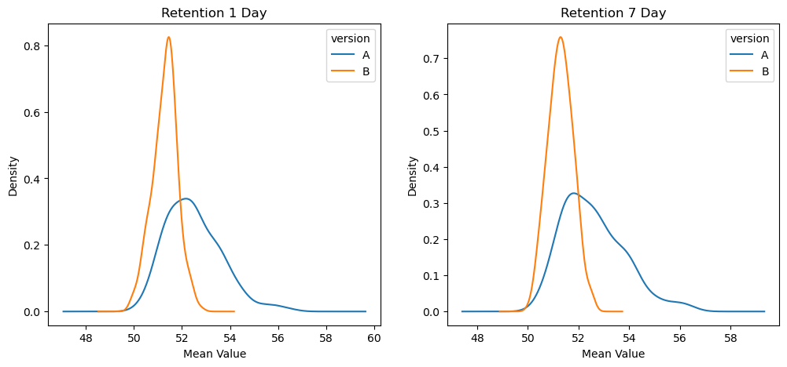

```python
fig, (ax3, ax4) = plt.subplots(1, 2, figsize=(12, 5))
mean_retention_1 = []
for i in range(200):
    bootstrap_sample = df.sample(frac = 1,replace=True)
    mean_1 = bootstrap_sample.groupby('version')['sum_gamerounds'].mean()
    mean_retention_1.append(mean_1)
mean_retention_1 = pd.DataFrame(mean_retention_1)

mean_retention_7 = []
for i in range(200):
    bootstrap_sample = df.sample(frac = 1,replace=True)
    mean_7 = bootstrap_sample.groupby('version')['sum_gamerounds'].mean()
    mean_retention_7.append(mean_7)
mean_retention_7 = pd.DataFrame(mean_retention_7)

mean_retention_1.plot(kind='density',ax=ax3)
ax3.set_title('Retention 1 Day')
ax3.set_xlabel('Mean Value')

mean_retention_7.plot(kind='density',ax=ax4)
plt.title('Retention 7 Day')
plt.xlabel('Mean Value')
```